# The Impact of Climate Extremes on Crop Yields in the Southeastern United States

Andrew

2019-04-01

# This is our living document which will evolve into a paper to be published on the impact of climate extremes on crop yields in the southeastern United States

## About this document

This document is written using R Markdown which means that all of the plots and statistics within it were created using actual code which will be presented alongside them. The data used in this research is all free and publicly available. Climate data (precipitation and temperature) was aquired from the [PRISM Climate Group](http://www.prism.oregonstate.edu/). Crop yield data was downloaded from the [USDA Quick Stats Database](https://quickstats.nass.usda.gov/).

### Crop Data

While USDA crop data is available back into the early nineteen hundreds, we utilized data available in 1981 and onward due to limitations imposed by the PRISM climate model. Corn, cotton, peanuts, soybeans and sweet potatoes were identified as major crops grown in the Carolinas and Georgia which have an abundance of crop yield data available within this time period.

### Climate Data

“PRISM datasets provide estimates of six basic climate elements: precipitation (ppt), minimum temperature (tmin), maximum temperature (tmax), mean dew point (tdmean), minimum vapor pressure deficit (vpdmin), and maximum vapor pressure deficit (vpdmax).” Precipitation and temperature are both avialable in daily, monthly and annual timescales at a spatial resolution of 4km (1981 - Present).

## Import formatted crop data

```r
crops <- read.csv(here("data","FinalCrops.csv"))
ppt <- read.csv(here("data","Num_ppt_Extreme_Days_Growing.csv"))
temp <- read.csv(here("data","Num_TMax_Extreme_Days_Growing.csv"))
zero <- read.csv(here("data","Num_Zero_Ppt_Days_Growing.csv"))
```

## Add join fields

```r
ppt$join <- paste0(ppt$County,ppt$Year)
temp$join <- paste0(temp$County,temp$Year)
zero$join <- paste0(zero$County,zero$Year)
```

## Load Shapefile of Study Area

```r
counties <- st_read(here("data","counties.shp"))%>%
  filter(STATEFP10 %in% c(37,45,13))
```

## Create subsets for each crop

```r
crops$FIPS <- paste0("F",crops$FIPS)
crops$join <- paste0(crops$FIPS,crops$Year)

crops <- merge(crops, ppt, by = "join")
crops <- merge(crops, temp, by = "join")
crops <- crops%>%
  select(-X.x,-Year.x,-Year.y,-County.x,-X.y,-County.y)
colnames(crops)[20:23] <- c("ExtPptDays","Year","Fips","ExtTempDays", "ZeroDays")
crops <- merge(crops, zero, by = "join")


soybeans <- crops%>%
  filter(Commodity == "SOYBEANS")%>%
  select(Value, FIPS,Year.x,ExtPptDays,ExtTempDays, NumZeroDays)

corn <-  crops%>%
  filter(Commodity == "CORN")%>%
  select(Value, FIPS,Year.x,ExtPptDays,ExtTempDays, NumZeroDays)

cotton <-  crops%>%
  filter(Commodity == "COTTON")%>%
  select(Value, FIPS,Year.x,ExtPptDays,ExtTempDays, NumZeroDays)

peanuts <-  crops%>%
  filter(Commodity == "PEANUTS")%>%
  select(Value, FIPS,Year.x,ExtPptDays,ExtTempDays, NumZeroDays)

sweetPotatoes <- crops%>%
  filter(Commodity == "SWEET POTATOES")%>%
  select(Value, FIPS,Year.x,ExtPptDays,ExtTempDays, NumZeroDays)
```

# Filter to keep only counties with >29 years of records

```r
# Soybeans
counts <- as.data.frame(table(soybeans$FIPS))
GT30 <- counts%>%
  filter(Freq > 29)
countiesGT30 <- GT30$Var1

soybeanCounts <- counts
soybeanCounties <- nrow(counts)
soybeanCountiesGT30 <- nrow(GT30)

soybeans <- soybeans%>%
  filter(FIPS %in% countiesGT30)

# Corn
counts <- as.data.frame(table(corn$FIPS))
GT30 <- counts%>%
  filter(Freq > 29)
countiesGT30 <- GT30$Var1

cornCounts <- counts
cornCounties <- nrow(counts)
cornCountiesGT30 <- nrow(GT30)

corn <- corn%>%
  filter(FIPS %in% countiesGT30)

# Cotton
counts <- as.data.frame(table(cotton$FIPS))
GT30 <- counts%>%
  filter(Freq > 29)
countiesGT30 <- GT30$Var1

cottonCounts <- counts
cottonCounties <- nrow(counts)
cottonCountiesGT30 <- nrow(GT30)

cotton <- cotton%>%
  filter(FIPS %in% countiesGT30)

# Peanuts
counts <- as.data.frame(table(peanuts$FIPS))
GT30 <- counts%>%
  filter(Freq > 29)
countiesGT30 <- GT30$Var1

peanutsCounts <- counts
peanutsCounties <- nrow(counts)
peanutsCountiesGT30 <- nrow(GT30)

peanuts <- peanuts%>%
  filter(FIPS %in% countiesGT30)

# Sweet Potatoes
counts <- as.data.frame(table(sweetPotatoes$FIPS))
GT30 <- counts%>%
  filter(Freq > 29)
countiesGT30 <- GT30$Var1

sweetPotatoCounts <- counts
sweetPotatoesCounties <- nrow(counts)
sweetPotatoesCountiesGT30 <- nrow(GT30)

sweetPotatoes <- sweetPotatoes%>%
  filter(FIPS %in% countiesGT30)
```

## Data Description

```
##             Crop Counties.Grown Counties.with.30.years.of.data Data.Points
## 1           Corn            303                            162        5674
## 2         Cotton            211                             91        3215
## 3        Peanuts            141                             64        2194
## 4       Soybeans            286                            148        5182
## 5 Sweet Potatoes             83                              6         199
```

# Crop Maps

## Corn

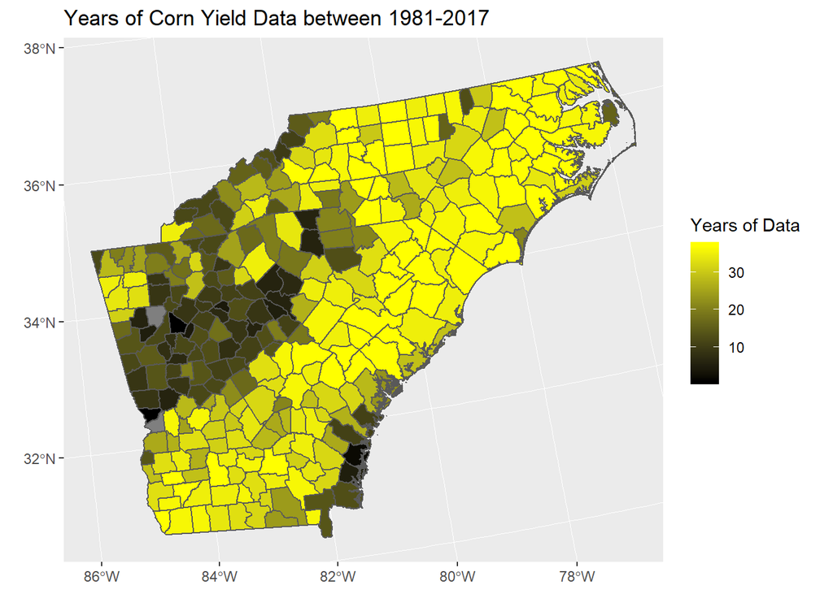

## Cotton

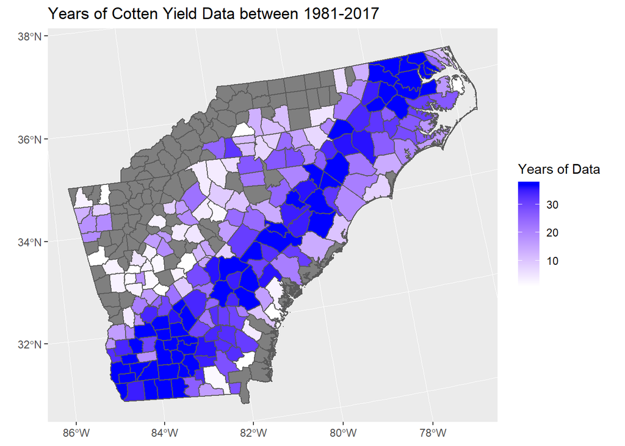

## Peanuts

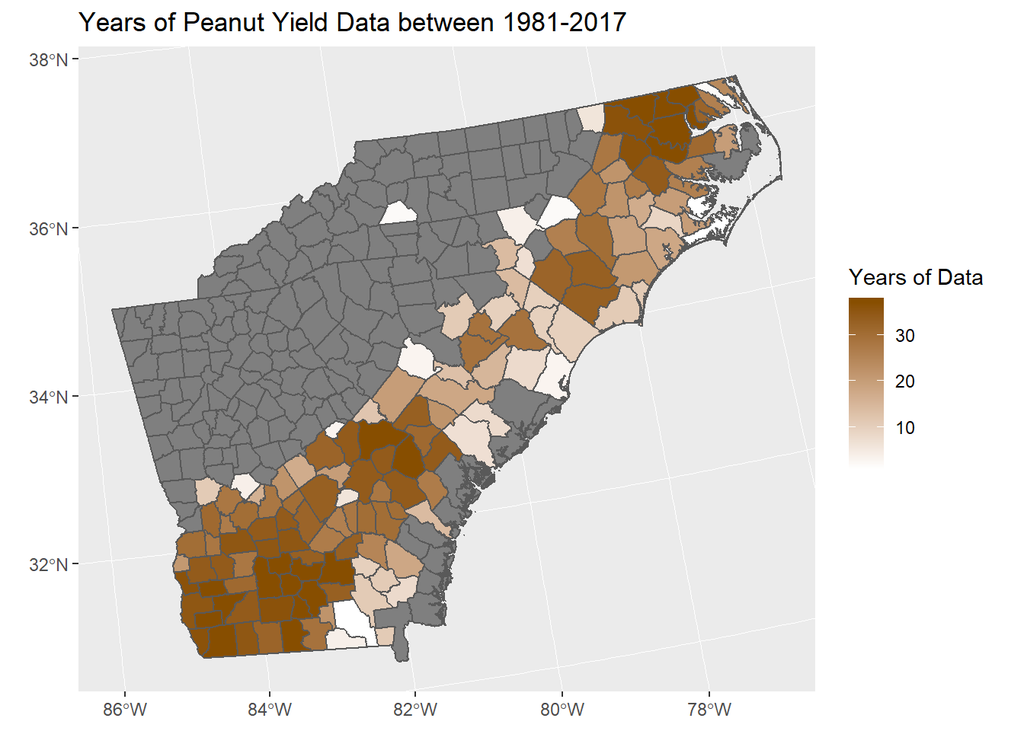

## Soybeans

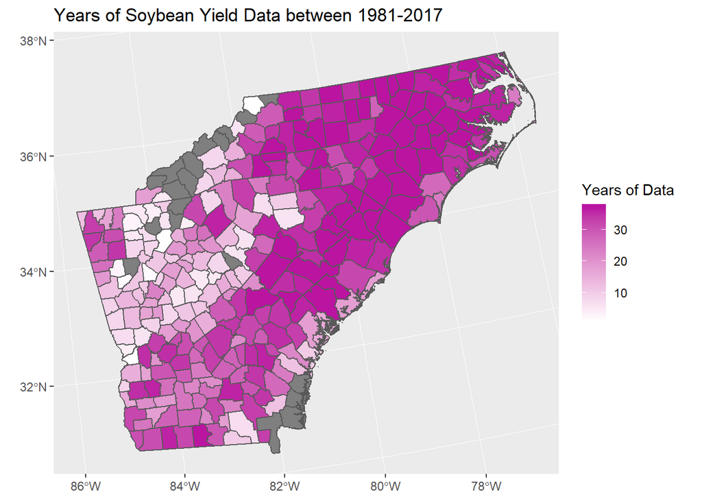

## Sweet Potatoes

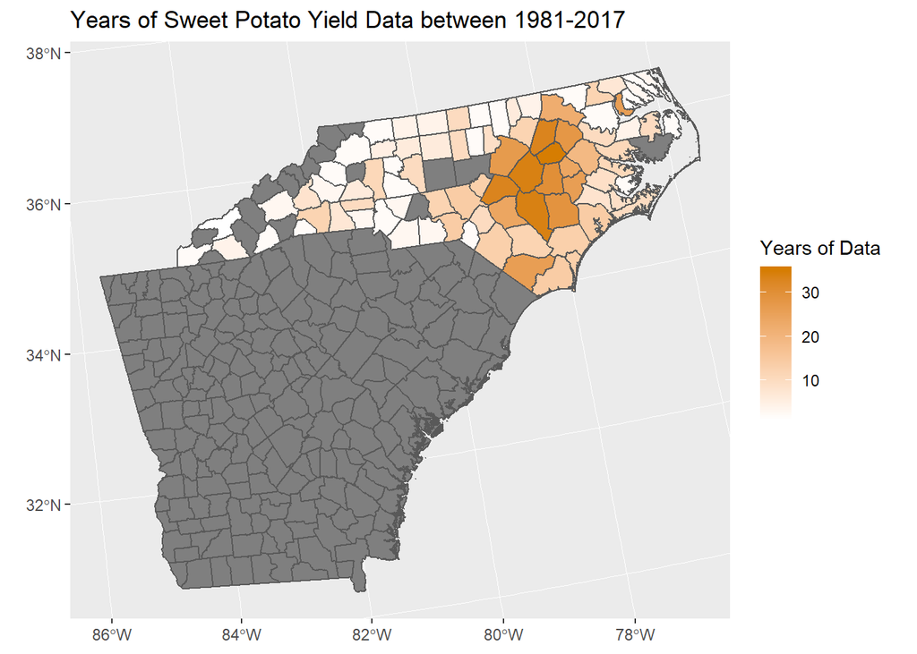

# Analysis by crop

## Soybeans

```r
# Soybeans

lmSoybeans <- lm(soybeans$Value~soybeans$ExtPptDays+soybeans$ExtTempDays+soybeans$Year+soybeans$NumZeroDays+factor(soybeans$FIPS))
summary(lmSoybeans)
```

```
##
## Call:
## lm(formula = soybeans$Value ~ soybeans$ExtPptDays + soybeans$ExtTempDays +
##     soybeans$Year + soybeans$NumZeroDays + factor(soybeans$FIPS))
##
## Residuals:
##      Min       1Q   Median       3Q      Max
## -22.7378  -2.9865   0.2161   3.1941  28.4374
##
## Coefficients:
##                               Estimate Std. Error t value Pr(>|t|)
## (Intercept)                 -6.320e+02  1.472e+01 -42.926  < 2e-16 ***
## soybeans$ExtPptDays          1.024e-01  2.445e-02   4.189 2.85e-05 ***
## soybeans$ExtTempDays        -1.922e-01  7.105e-03 -27.056  < 2e-16 ***
## soybeans$Year                3.340e-01  7.244e-03  46.106  < 2e-16 ***
## soybeans$NumZeroDays        -4.641e-02  8.518e-03  -5.449 5.30e-08 ***
## factor(soybeans$FIPS)F13005 -2.273e+00  1.294e+00  -1.756 0.079079 .
## factor(soybeans$FIPS)F13015  1.369e-01  1.252e+00   0.109 0.912972
## factor(soybeans$FIPS)F13019 -5.482e-01  1.272e+00  -0.431 0.666436
## factor(soybeans$FIPS)F13023 -3.552e+00  1.295e+00  -2.743 0.006116 **
## factor(soybeans$FIPS)F13027  5.184e+00  1.227e+00   4.227 2.41e-05 ***
## factor(soybeans$FIPS)F13031 -2.578e+00  1.243e+00  -2.074 0.038140 *
## factor(soybeans$FIPS)F13033 -4.869e+00  1.227e+00  -3.969 7.31e-05 ***
## factor(soybeans$FIPS)F13055 -3.182e-01  1.253e+00  -0.254 0.799571
## factor(soybeans$FIPS)F13069 -8.173e-02  1.235e+00  -0.066 0.947226
## factor(soybeans$FIPS)F13087  5.112e+00  1.282e+00   3.987 6.79e-05 ***
## factor(soybeans$FIPS)F13091 -1.361e+00  1.262e+00  -1.078 0.280895
## factor(soybeans$FIPS)F13093 -3.633e+00  1.255e+00  -2.895 0.003802 **
## factor(soybeans$FIPS)F13099  4.698e-01  1.272e+00   0.369 0.711889
## factor(soybeans$FIPS)F13103 -2.681e+00  1.262e+00  -2.125 0.033635 *
## factor(soybeans$FIPS)F13107 -3.058e+00  1.272e+00  -2.404 0.016264 *
## factor(soybeans$FIPS)F13109 -1.886e+00  1.273e+00  -1.481 0.138600
## factor(soybeans$FIPS)F13129  4.341e+00  1.284e+00   3.381 0.000727 ***
## factor(soybeans$FIPS)F13131  1.880e+00  1.235e+00   1.523 0.127838
## factor(soybeans$FIPS)F13153 -5.725e+00  1.283e+00  -4.461 8.33e-06 ***
## factor(soybeans$FIPS)F13163 -2.834e+00  1.254e+00  -2.261 0.023814 *
## factor(soybeans$FIPS)F13165 -2.502e+00  1.263e+00  -1.982 0.047572 *
## factor(soybeans$FIPS)F13167 -6.473e+00  1.253e+00  -5.166 2.49e-07 ***
## factor(soybeans$FIPS)F13175 -4.911e+00  1.252e+00  -3.922 8.91e-05 ***
## factor(soybeans$FIPS)F13185  3.404e-01  1.293e+00   0.263 0.792388
```

[output cut: 114 more lines]

```
## factor(soybeans$FIPS)F45069 -4.900e+00  1.227e+00  -3.993 6.62e-05 ***
## factor(soybeans$FIPS)F45071 -4.110e+00  1.237e+00  -3.322 0.000901 ***
## factor(soybeans$FIPS)F45073 -5.315e+00  1.274e+00  -4.171 3.08e-05 ***
## factor(soybeans$FIPS)F45075 -3.440e+00  1.228e+00  -2.802 0.005102 **
## factor(soybeans$FIPS)F45079 -5.799e+00  1.243e+00  -4.664 3.18e-06 ***
## factor(soybeans$FIPS)F45083 -3.894e+00  1.262e+00  -3.085 0.002047 **
## factor(soybeans$FIPS)F45085 -3.246e+00  1.227e+00  -2.645 0.008190 **
## factor(soybeans$FIPS)F45089 -3.703e+00  1.235e+00  -2.999 0.002718 **
## factor(soybeans$FIPS)F45091 -6.495e+00  1.274e+00  -5.098 3.55e-07 ***
## ---
## Signif. codes:  0 '***' 0.001 '**' 0.01 '*' 0.05 '.' 0.1 ' ' 1
##
## Residual standard error: 5.163 on 5030 degrees of freedom
## Multiple R-squared:  0.561,  Adjusted R-squared:  0.5478
## F-statistic: 42.56 on 151 and 5030 DF,  p-value: < 2.2e-16
```

```r
summary(lmSoybeans)$r.squared
```

```
## [1] 0.5609784
```

```r
#Cluster

#model <- plm(price ~ sales, model = 'within', data = Cigar)
#G <- length(unique(Cigar$state))
#c <- G/(G - 1)
#coeftest(model,c * vcovHC(model, type = "HC1", cluster = "group"))
```

## Corn

```r
# Corn

lmCorn <- lm(corn$Value~corn$ExtPptDays+corn$ExtTempDays+corn$Year+corn$NumZeroDays+factor(corn$FIPS))
summary(lmCorn)
```

```
##
## Call:
## lm(formula = corn$Value ~ corn$ExtPptDays + corn$ExtTempDays +
##     corn$Year + corn$NumZeroDays + factor(corn$FIPS))
##
## Residuals:
##     Min      1Q  Median      3Q     Max
## -80.391 -13.310  -0.111  13.131 123.639
##
## Coefficients:
##                           Estimate Std. Error t value Pr(>|t|)
## (Intercept)             -3.535e+03  5.801e+01 -60.932  < 2e-16 ***
## corn$ExtPptDays          4.114e-01  9.474e-02   4.343 1.43e-05 ***
## corn$ExtTempDays        -9.522e-01  2.759e-02 -34.519  < 2e-16 ***
## corn$Year                1.817e+00  2.856e-02  63.630  < 2e-16 ***
## corn$NumZeroDays         1.530e-02  3.341e-02   0.458 0.646979
## factor(corn$FIPS)F13003  1.691e+01  5.085e+00   3.325 0.000888 ***
## factor(corn$FIPS)F13005 -4.076e+00  5.248e+00  -0.777 0.437352
## factor(corn$FIPS)F13007  6.481e+01  5.017e+00  12.919  < 2e-16 ***
## factor(corn$FIPS)F13015  1.353e+01  5.161e+00   2.622 0.008769 **
## factor(corn$FIPS)F13017  2.526e+01  5.203e+00   4.855 1.24e-06 ***
## factor(corn$FIPS)F13019  1.314e+01  5.161e+00   2.547 0.010904 *
## factor(corn$FIPS)F13023  2.774e+01  5.207e+00   5.327 1.04e-07 ***
## factor(corn$FIPS)F13025 -1.922e+01  5.208e+00  -3.691 0.000225 ***
## factor(corn$FIPS)F13027  1.304e+01  5.161e+00   2.526 0.011556 *
## factor(corn$FIPS)F13031  1.984e+00  5.202e+00   0.381 0.702947
## factor(corn$FIPS)F13033  2.914e+01  5.015e+00   5.811 6.56e-09 ***
## factor(corn$FIPS)F13037  5.995e+01  5.025e+00  11.930  < 2e-16 ***
## factor(corn$FIPS)F13055 -7.720e-01  5.088e+00  -0.152 0.879409
## factor(corn$FIPS)F13069  1.620e+01  5.015e+00   3.230 0.001247 **
## factor(corn$FIPS)F13071  2.540e+01  5.085e+00   4.995 6.06e-07 ***
## factor(corn$FIPS)F13075  1.029e+01  5.050e+00   2.037 0.041699 *
## factor(corn$FIPS)F13081  1.171e+01  5.260e+00   2.227 0.026018 *
## factor(corn$FIPS)F13087  4.766e+01  5.049e+00   9.440  < 2e-16 ***
## factor(corn$FIPS)F13091  1.711e+01  5.124e+00   3.340 0.000842 ***
## factor(corn$FIPS)F13093  1.892e+01  5.254e+00   3.601 0.000320 ***
## factor(corn$FIPS)F13099  4.739e+01  5.162e+00   9.181  < 2e-16 ***
## factor(corn$FIPS)F13103 -9.808e+00  5.203e+00  -1.885 0.059455 .
## factor(corn$FIPS)F13107  8.974e-01  5.051e+00   0.178 0.858976
## factor(corn$FIPS)F13109 -2.050e+00  5.208e+00  -0.394 0.693871
```

[output cut: 128 more lines]

```
## factor(corn$FIPS)F45067  2.443e+00  5.084e+00   0.480 0.630934
## factor(corn$FIPS)F45069 -9.231e-01  5.017e+00  -0.184 0.854037
## factor(corn$FIPS)F45071 -1.147e+01  5.255e+00  -2.182 0.029133 *
## factor(corn$FIPS)F45075  6.958e+00  5.020e+00   1.386 0.165819
## factor(corn$FIPS)F45079  3.521e+00  5.202e+00   0.677 0.498545
## factor(corn$FIPS)F45081 -1.258e+01  5.097e+00  -2.469 0.013583 *
## factor(corn$FIPS)F45083 -4.531e+00  5.123e+00  -0.885 0.376461
## factor(corn$FIPS)F45085  9.188e+00  5.016e+00   1.832 0.067077 .
## factor(corn$FIPS)F45089 -9.552e+00  5.015e+00  -1.905 0.056884 .
## ---
## Signif. codes:  0 '***' 0.001 '**' 0.01 '*' 0.05 '.' 0.1 ' ' 1
##
## Residual standard error: 21.27 on 5508 degrees of freedom
## Multiple R-squared:  0.6598, Adjusted R-squared:  0.6496
## F-statistic: 64.74 on 165 and 5508 DF,  p-value: < 2.2e-16
```

```r
summary(lmCorn)$r.squared
```

```
## [1] 0.6598031
```

## Cotton

```r
# Cotton

lmCotton <- lm(cotton$Value~cotton$ExtPptDays+cotton$ExtTempDays+cotton$Year+cotton$NumZeroDays+factor(cotton$FIPS))
summary(lmCotton)
```

```
##
## Call:
## lm(formula = cotton$Value ~ cotton$ExtPptDays + cotton$ExtTempDays +
##     cotton$Year + cotton$NumZeroDays + factor(cotton$FIPS))
##
## Residuals:
##     Min      1Q  Median      3Q     Max
## -534.26 -103.55   -2.88  104.39  458.10
##
## Coefficients:
##                             Estimate Std. Error t value Pr(>|t|)
## (Intercept)               -1.821e+04  5.269e+02 -34.557  < 2e-16 ***
## cotton$ExtPptDays         -4.731e+00  9.078e-01  -5.211 2.00e-07 ***
## cotton$ExtTempDays        -4.829e+00  2.466e-01 -19.580  < 2e-16 ***
## cotton$Year                9.479e+00  2.599e-01  36.464  < 2e-16 ***
## cotton$NumZeroDays         6.915e-01  3.088e-01   2.239 0.025203 *
## factor(cotton$FIPS)F13003  7.375e+01  3.584e+01   2.058 0.039684 *
## factor(cotton$FIPS)F13005 -4.256e+01  3.639e+01  -1.169 0.242315
## factor(cotton$FIPS)F13007  1.704e+02  3.540e+01   4.812 1.56e-06 ***
## factor(cotton$FIPS)F13017  4.244e+01  3.540e+01   1.199 0.230687
## factor(cotton$FIPS)F13019  2.338e+01  3.537e+01   0.661 0.508777
## factor(cotton$FIPS)F13023 -4.934e+01  3.549e+01  -1.390 0.164563
## factor(cotton$FIPS)F13027  7.840e+01  3.537e+01   2.216 0.026735 *
## factor(cotton$FIPS)F13031 -2.419e+01  3.537e+01  -0.684 0.494058
## factor(cotton$FIPS)F13033 -5.038e+00  3.538e+01  -0.142 0.886764
## factor(cotton$FIPS)F13037  1.694e+02  3.552e+01   4.768 1.95e-06 ***
## factor(cotton$FIPS)F13043 -7.407e+01  3.624e+01  -2.044 0.041053 *
## factor(cotton$FIPS)F13061  6.576e+01  3.650e+01   1.802 0.071701 .
## factor(cotton$FIPS)F13069  1.662e+01  3.560e+01   0.467 0.640699
## factor(cotton$FIPS)F13071  1.354e+02  3.539e+01   3.827 0.000132 ***
## factor(cotton$FIPS)F13075  9.688e+01  3.540e+01   2.737 0.006240 **
## factor(cotton$FIPS)F13081 -3.876e+01  3.557e+01  -1.090 0.275975
## factor(cotton$FIPS)F13087  2.559e+02  3.584e+01   7.140 1.15e-12 ***
## factor(cotton$FIPS)F13091  1.722e+01  3.540e+01   0.486 0.626795
## factor(cotton$FIPS)F13093  1.081e+01  3.550e+01   0.304 0.760780
## factor(cotton$FIPS)F13099  1.269e+02  3.540e+01   3.584 0.000343 ***
## factor(cotton$FIPS)F13107 -4.663e+01  3.541e+01  -1.317 0.187928
## factor(cotton$FIPS)F13131  9.605e+01  3.537e+01   2.716 0.006651 **
## factor(cotton$FIPS)F13153 -5.575e+01  3.735e+01  -1.493 0.135646
## factor(cotton$FIPS)F13155  4.584e+01  3.537e+01   1.296 0.195134
```

[output cut: 57 more lines]

```
## factor(cotton$FIPS)F45035 -9.878e+01  3.695e+01  -2.673 0.007547 **
## factor(cotton$FIPS)F45041 -9.093e+01  3.541e+01  -2.568 0.010276 *
## factor(cotton$FIPS)F45049 -1.799e+01  3.561e+01  -0.505 0.613386
## factor(cotton$FIPS)F45061 -2.396e+01  3.551e+01  -0.675 0.499860
## factor(cotton$FIPS)F45067 -4.049e+01  3.666e+01  -1.105 0.269434
## factor(cotton$FIPS)F45069 -1.045e+01  3.542e+01  -0.295 0.768036
## factor(cotton$FIPS)F45075  4.670e+01  3.541e+01   1.319 0.187365
## factor(cotton$FIPS)F45085  1.554e+01  3.588e+01   0.433 0.664881
## factor(cotton$FIPS)F45089  1.160e+01  3.537e+01   0.328 0.743027
## ---
## Signif. codes:  0 '***' 0.001 '**' 0.01 '*' 0.05 '.' 0.1 ' ' 1
##
## Residual standard error: 147.7 on 3120 degrees of freedom
## Multiple R-squared:  0.4496, Adjusted R-squared:  0.433
## F-statistic: 27.11 on 94 and 3120 DF,  p-value: < 2.2e-16
```

```r
summary(lmCotton)$r.squared
```

```
## [1] 0.4495694
```

## Peanuts

```r
# Peanuts

lmPeanuts <- lm(peanuts$Value~peanuts$ExtPptDays+peanuts$ExtTempDays+peanuts$Year+peanuts$NumZeroDays+factor(peanuts$FIPS))
summary(lmPeanuts)
```

```
##
## Call:
## lm(formula = peanuts$Value ~ peanuts$ExtPptDays + peanuts$ExtTempDays +
##     peanuts$Year + peanuts$NumZeroDays + factor(peanuts$FIPS))
##
## Residuals:
##      Min       1Q   Median       3Q      Max
## -1549.44  -376.09   -13.41   358.05  2023.95
##
## Coefficients:
##                              Estimate Std. Error t value Pr(>|t|)
## (Intercept)                -7.019e+04  2.382e+03 -29.467  < 2e-16 ***
## peanuts$ExtPptDays         -1.249e+01  4.044e+00  -3.088 0.002044 **
## peanuts$ExtTempDays        -1.471e+01  1.092e+00 -13.470  < 2e-16 ***
## peanuts$Year                3.670e+01  1.177e+00  31.188  < 2e-16 ***
## peanuts$NumZeroDays         9.658e-01  1.364e+00   0.708 0.479120
## factor(peanuts$FIPS)F13007  8.926e+02  1.307e+02   6.828 1.12e-11 ***
## factor(peanuts$FIPS)F13017  2.804e+02  1.344e+02   2.086 0.037062 *
## factor(peanuts$FIPS)F13019 -3.127e+01  1.305e+02  -0.240 0.810647
## factor(peanuts$FIPS)F13023 -1.696e+02  1.382e+02  -1.227 0.219797
## factor(peanuts$FIPS)F13027  1.674e+02  1.305e+02   1.283 0.199639
## factor(peanuts$FIPS)F13031 -6.535e+01  1.332e+02  -0.491 0.623629
## factor(peanuts$FIPS)F13033  3.582e+02  1.305e+02   2.744 0.006112 **
## factor(peanuts$FIPS)F13037  6.423e+02  1.314e+02   4.887 1.10e-06 ***
## factor(peanuts$FIPS)F13061  1.771e+02  1.322e+02   1.340 0.180292
## factor(peanuts$FIPS)F13069  4.684e+01  1.305e+02   0.359 0.719667
## factor(peanuts$FIPS)F13071  2.453e+02  1.315e+02   1.866 0.062176 .
## factor(peanuts$FIPS)F13075  6.670e+01  1.307e+02   0.510 0.609859
## factor(peanuts$FIPS)F13081 -4.617e+02  1.334e+02  -3.460 0.000551 ***
## factor(peanuts$FIPS)F13087  9.923e+02  1.304e+02   7.607 4.17e-14 ***
## factor(peanuts$FIPS)F13091 -2.686e+01  1.355e+02  -0.198 0.842896
## factor(peanuts$FIPS)F13093 -3.133e+02  1.341e+02  -2.337 0.019550 *
## factor(peanuts$FIPS)F13095  5.659e+02  1.367e+02   4.140 3.61e-05 ***
## factor(peanuts$FIPS)F13099  4.476e+02  1.325e+02   3.379 0.000741 ***
## factor(peanuts$FIPS)F13107 -2.363e+02  1.334e+02  -1.771 0.076680 .
## factor(peanuts$FIPS)F13109  6.611e+01  1.381e+02   0.479 0.632167
## factor(peanuts$FIPS)F13131  3.446e+02  1.322e+02   2.607 0.009206 **
## factor(peanuts$FIPS)F13155  1.717e+02  1.305e+02   1.316 0.188381
## factor(peanuts$FIPS)F13161 -1.285e+02  1.342e+02  -0.957 0.338472
## factor(peanuts$FIPS)F13163  7.631e+01  1.337e+02   0.571 0.568281
```

[output cut: 30 more lines]

```
## factor(peanuts$FIPS)F37131  2.013e+02  1.311e+02   1.536 0.124702
## factor(peanuts$FIPS)F37143  5.429e+02  1.361e+02   3.989 6.86e-05 ***
## factor(peanuts$FIPS)F37147 -1.482e+02  1.336e+02  -1.109 0.267573
## factor(peanuts$FIPS)F37155 -1.032e+02  1.352e+02  -0.764 0.445131
## factor(peanuts$FIPS)F37163 -2.660e+02  1.374e+02  -1.935 0.053088 .
## factor(peanuts$FIPS)F37187  5.194e+00  1.371e+02   0.038 0.969789
## factor(peanuts$FIPS)F45005  2.264e+02  1.369e+02   1.654 0.098354 .
## factor(peanuts$FIPS)F45011  5.725e+01  1.343e+02   0.426 0.669880
## factor(peanuts$FIPS)F45049  1.790e+02  1.334e+02   1.342 0.179694
## ---
## Signif. codes:  0 '***' 0.001 '**' 0.01 '*' 0.05 '.' 0.1 ' ' 1
##
## Residual standard error: 544.6 on 2126 degrees of freedom
## Multiple R-squared:  0.5095, Adjusted R-squared:  0.4941
## F-statistic: 32.97 on 67 and 2126 DF,  p-value: < 2.2e-16
```

```r
summary(lmPeanuts)$r.squared
```

```
## [1] 0.5095479
```

## Sweet Potatoes

```r
# Sweet Potatoes


lmSweetPotatoes<- lm(sweetPotatoes$Value~sweetPotatoes$ExtPptDays+sweetPotatoes$ExtTempDays+sweetPotatoes$Year+sweetPotatoes$NumZeroDays+factor(sweetPotatoes$FIPS))
summary(lmSweetPotatoes)
```

```
##
## Call:
## lm(formula = sweetPotatoes$Value ~ sweetPotatoes$ExtPptDays +
##     sweetPotatoes$ExtTempDays + sweetPotatoes$Year + sweetPotatoes$NumZeroDays +
##     factor(sweetPotatoes$FIPS))
##
## Residuals:
##     Min      1Q  Median      3Q     Max
## -58.389 -14.339   1.599  13.994  57.229
##
## Coefficients:
##                                    Estimate Std. Error t value Pr(>|t|)
## (Intercept)                      -5255.2598   348.6668 -15.072  < 2e-16
## sweetPotatoes$ExtPptDays            -2.6054     0.6285  -4.145 5.12e-05
## sweetPotatoes$ExtTempDays           -0.6483     0.1868  -3.470 0.000644
## sweetPotatoes$Year                   2.6963     0.1717  15.700  < 2e-16
## sweetPotatoes$NumZeroDays            0.5037     0.2019   2.495 0.013445
## factor(sweetPotatoes$FIPS)F37101     0.5593     5.5778   0.100 0.920234
## factor(sweetPotatoes$FIPS)F37127     9.9285     5.5845   1.778 0.077034
## factor(sweetPotatoes$FIPS)F37163    16.5165     5.9235   2.788 0.005841
## factor(sweetPotatoes$FIPS)F37191     9.8519     5.7562   1.712 0.088622
## factor(sweetPotatoes$FIPS)F37195    20.3474     5.5306   3.679 0.000305
##
## (Intercept)                      ***
## sweetPotatoes$ExtPptDays         ***
## sweetPotatoes$ExtTempDays        ***
## sweetPotatoes$Year               ***
## sweetPotatoes$NumZeroDays        *
## factor(sweetPotatoes$FIPS)F37101
## factor(sweetPotatoes$FIPS)F37127 .
## factor(sweetPotatoes$FIPS)F37163 **
## factor(sweetPotatoes$FIPS)F37191 .
## factor(sweetPotatoes$FIPS)F37195 ***
## ---
## Signif. codes:  0 '***' 0.001 '**' 0.01 '*' 0.05 '.' 0.1 ' ' 1
##
## Residual standard error: 22.68 on 189 degrees of freedom
## Multiple R-squared:  0.6065, Adjusted R-squared:  0.5877
## F-statistic: 32.36 on 9 and 189 DF,  p-value: < 2.2e-16
```

```r
summary(lmSweetPotatoes)$r.squared
```

```
## [1] 0.6064822
```

## References

Daly, Christopher, et al. [“Physiographically sensitive mapping of climatological temperature and precipitation across the conterminous United States.”](https://rmets.onlinelibrary.wiley.com/doi/abs/10.1002/joc.1688) International Journal of Climatology: a Journal of the Royal Meteorological Society 28.15 (2008): 2031-2064.